# Analysis of Experiment 3

Joern Alexander Quent

29/01/2021

Note the analysis here only includes O-shaped rooms.

Current balance: £147.04

# Results

## Responses during video

### Video 1

For 44.8 % of participants we didn’t register the 44 responses. Some of this issue due to the fact that if the key is pressed to long multiple response are registered. Only 3.4 of all, gave fewer than 44 responses. Therefore it seems that compliance is quite good. Also note that here we also include people who might not did or might be excluded from the memory analysis.

As expected, those people who gave 44 response give around the same time. The average inter-response-interval (IRI) is 7857 (36) msec (SD in brackets). This tiny SD is not unexpected as the time between objects was the same for all participants.

One way of checking whether participants are paying attention to the video is to correlate their responses to the responses of everyone else. To make things easier, I just do this with people who have given exactly 44 responses as I don’t want to fiddle around with removing multiple responses.

This procedure works quite well. The correlations for this subset of all participants who watch the video ranges between r = .67 and r = .94.

If I bootstrap responses by randomly sampling 0 and 1, the upper 95% value is r = .25, which means that each subject for which I estimated this congruency is well above that.

## Memory task

Average transformed (overall) accuracy is treated as an outlier if it’s above/below 2 median absolute deviations from the median. The let to the exclusion of 6.4 % of the data.

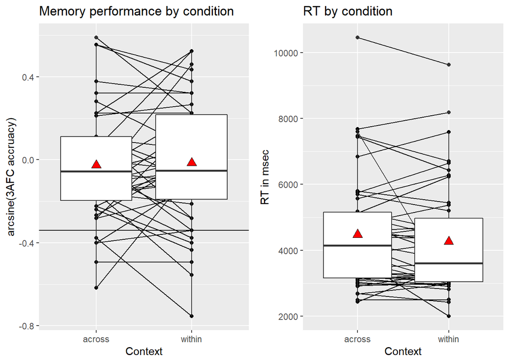

I analyse the data (N = 43) above with a paired and directed t-test. For accuracy the result is $BF_{01}$ = 4.72 and for RT the result is $BF_{01}$ = 1.09. So there is small evidence against an effect.

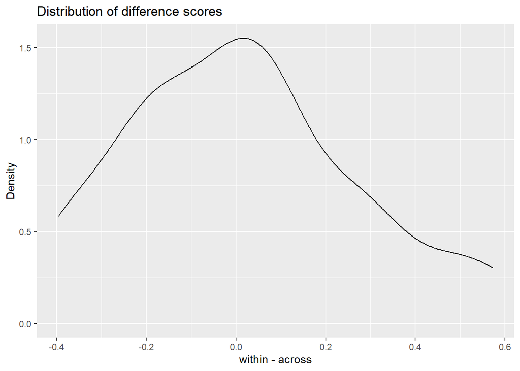

The distribution of difference seems to be fairly focussed around zero.

In the following, I am trying to dissect the memory effect a bit. First, there is no difference between the counterbalancing conditions.

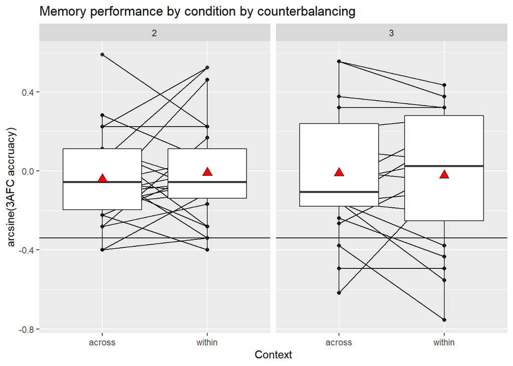

Furthermore, there doesn’t seems to be a difference between first memory test and the second memory test.

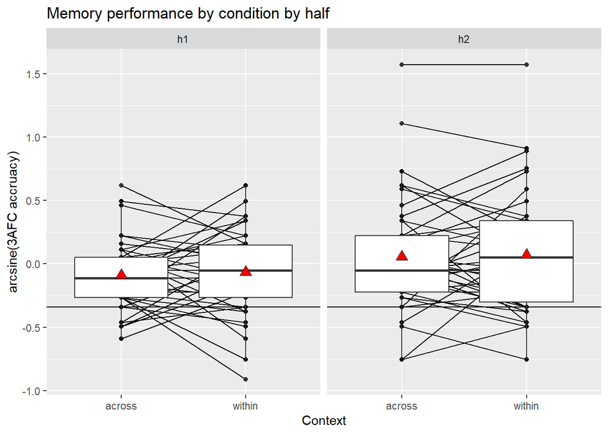

There is a correlation between average RT and average accuracy r = .349, p = .02.

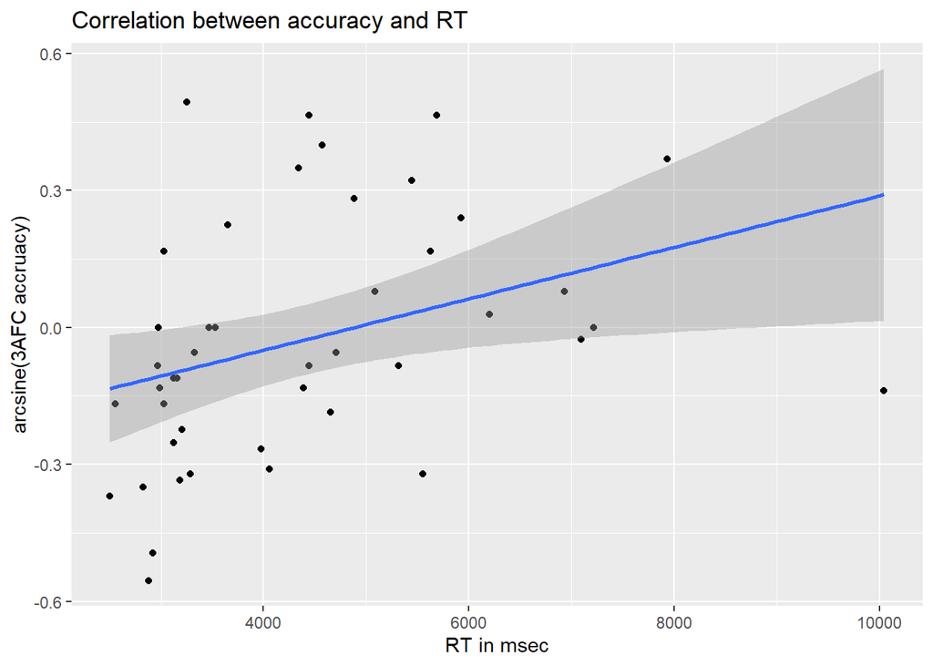

### Additional memory analysis

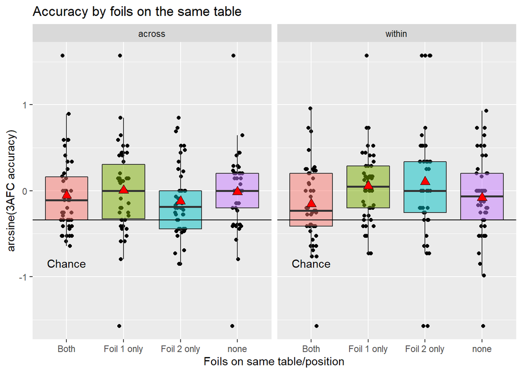

Estimate

SE

Z

P

Sig

(Intercept)

0.04

0.12

0.33

0.7442

contextwithin

-0.18

0.13

-1.30

0.1937

foil1_sameTableTRUE

0.03

0.14

0.20

0.8442

foil2_sameTableTRUE

-0.20

0.14

-1.48

0.1394

contextwithin:foil1_sameTableTRUE

0.24

0.19

1.25

0.2096

contextwithin:foil2_sameTableTRUE

0.49

0.22

2.28

0.0228

foil1_sameTableTRUE:foil2_sameTableTRUE

0.03

0.20

0.16

0.8692

contextwithin:foil1_sameTableTRUE:foil2_sameTableTRUE

-0.72

0.29

-2.49

0.0128

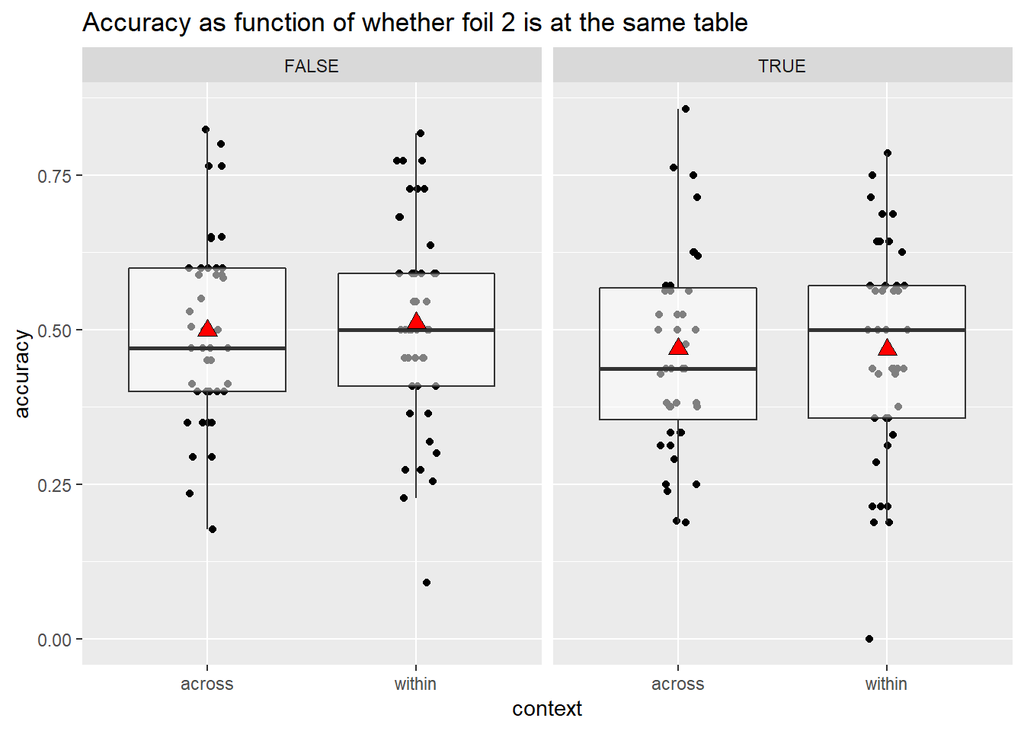

## Debrief

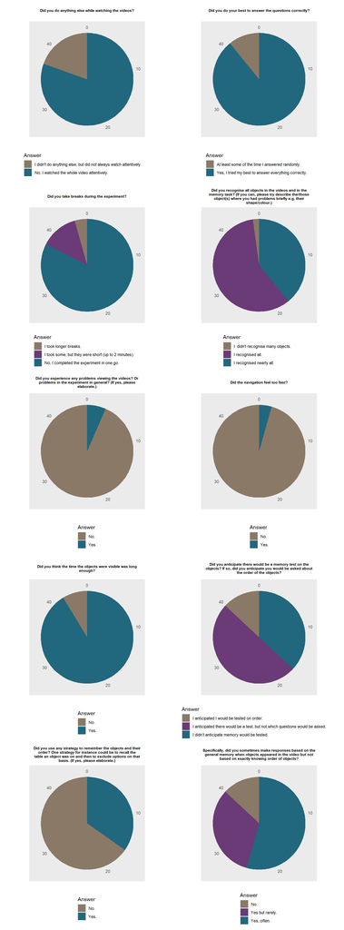

### Further comments regarding the questions

**Subject: 15168** *Did you use any strategy to remember the objects and their order? One strategy for instance could be to recall the table an object was on and then to exclude options on that basis. (If yes, please elaborate.)*:  
story telling with objects  
**Subject: 15175** *Did you recognise all objects in the videos and in the memory task? (If you can, please try describe the/those object(s) where you had problems briefly e.g. their shape/colour.)*:  
I don’t remember seeing a football  
**Subject: 15176** *Did you recognise all objects in the videos and in the memory task? (If you can, please try describe the/those object(s) where you had problems briefly e.g. their shape/colour.)*:  
Mostly the smaller object such as the red mug and the jar of pencils  
**Subject: 15184** *Did you use any strategy to remember the objects and their order? One strategy for instance could be to recall the table an object was on and then to exclude options on that basis. (If yes, please elaborate.)*:  
I tried to remember on which side the object was  
**Subject: 15180** *Did you recognise all objects in the videos and in the memory task? (If you can, please try describe the/those object(s) where you had problems briefly e.g. their shape/colour.)*:  
yellow duck, futball ball, skateboard.  
**Subject: 15200** *Did you use any strategy to remember the objects and their order? One strategy for instance could be to recall the table an object was on and then to exclude options on that basis. (If yes, please elaborate.)*:  
I tried to make pairs of objects

**Subject: 15205** *Did you experience any problems viewing the videos? Or problems in the experiment in general? (If yes, please elaborate.)*:  
Yes, at first there was a delay in moving forward after the verification video but it was just a matter of waiting a little longer. After that all went well.  
**Subject: 15206** *Did you recognise all objects in the videos and in the memory task? (If you can, please try describe the/those object(s) where you had problems briefly e.g. their shape/colour.)*:  
Green pots or watering cans  
**Subject: 15206** *Did you experience any problems viewing the videos? Or problems in the experiment in general? (If yes, please elaborate.)*:  
The first video started before I could read the instructions properly.  
**Subject: 15210** *Did you use any strategy to remember the objects and their order? One strategy for instance could be to recall the table an object was on and then to exclude options on that basis. (If yes, please elaborate.)*:  
I tried to make a little phrase in my head. Like I thought “business sucks reversed” to remember that a vacuum cleaner (sucks) came before the briefcase.  
**Subject: 15207** *Did you recognise all objects in the videos and in the memory task? (If you can, please try describe the/those object(s) where you had problems briefly e.g. their shape/colour.)*:  
a small black and white rectangular object  
**Subject: 15207** *Did you use any strategy to remember the objects and their order? One strategy for instance could be to recall the table an object was on and then to exclude options on that basis. (If yes, please elaborate.)*:  
I tried to logically link the objects, for example : duck in basket, piano on basket… Or : I put my shoes on, I take the sweeper and I pick the toy up…  
**Subject: 15330** *Did you use any strategy to remember the objects and their order? One strategy for instance could be to recall the table an object was on and then to exclude options on that basis. (If yes, please elaborate.)*:  
trying to find a connection between the objects, but it almost never worked or I couldn’t find it  
**Subject: 15328** *Did you recognise all objects in the videos and in the memory task? (If you can, please try describe the/those object(s) where you had problems briefly e.g. their shape/colour.)*:  
I don’t have a good memory so was kinda hard to remember the sequence of the objects.  
**Subject: 15326** *Did you recognise all objects in the videos and in the memory task? (If you can, please try describe the/those object(s) where you had problems briefly e.g. their shape/colour.)*:  
Couldn’t remember the red mug from the first batch  
**Subject: 15340** *Did you use any strategy to remember the objects and their order? One strategy for instance could be to recall the table an object was on and then to exclude options on that basis. (If yes, please elaborate.)*:  
In the second set of experiments I tried to make a story fit the sequence, eg the workers had their ‘yellow hard-hat’ on playing ‘football’ then they knocked over the ‘statue head’, but there were too many items to carry this on for very long.  
**Subject: 15340** *Specifically, did you sometimes make responses based on the general memory when objects appeared in the video but not based on exactly knowing order of objects?*:  
I tried to remember a sequence firstly but it got too hard  
**Subject: 15337** *Did you recognise all objects in the videos and in the memory task? (If you can, please try describe the/those object(s) where you had problems briefly e.g. their shape/colour.)*:  
There was one small white kettle looking thing that I wasn’t sure what it was. (Not the obvious kettle but a slightly smaller one)  
**Subject: 15337** *Did you experience any problems viewing the videos? Or problems in the experiment in general? (If yes, please elaborate.)*:  
N/A  
**Subject: 15337** *Did you use any strategy to remember the objects and their order? One strategy for instance could be to recall the table an object was on and then to exclude options on that basis. (If yes, please elaborate.)*:  
Sometimes if the objects started with the same letter i’d remember they were in the same room such as tennis racket/telescope.  
**Subject: 15337** *Specifically, did you sometimes make responses based on the general memory when objects appeared in the video but not based on exactly knowing order of objects?*:  
I often didn’t remember exact order so I tried to rule out objects I thought came a bit earlier/later  
**Subject: 15333** *Did you use any strategy to remember the objects and their order? One strategy for instance could be to recall the table an object was on and then to exclude options on that basis. (If yes, please elaborate.)*:  
I tried to memorize which objects appeared in which table and tried to “connect” them in my head by repeating the objects i was seeing out loud.  
**Subject: 15329** *Did you use any strategy to remember the objects and their order? One strategy for instance could be to recall the table an object was on and then to exclude options on that basis. (If yes, please elaborate.)*:  
I was creating a story around the objects to relate them one after the other. I was particularly looking for strong connections that later one would help me guess which one follows. For example, I related dumbbells and pillow which both relate to fitness like training and resting. For some it was easier for others it was harder I did not make any connection so I moved on with these ones.  
**Subject: 15329** *Specifically, did you sometimes make responses based on the general memory when objects appeared in the video but not based on exactly knowing order of objects?*:  
I think Yes I based my guess on the objects I recalled were in order. However, I’m not sure if I have fully understood this questions.  
**Subject: 15334** *Did you use any strategy to remember the objects and their order? One strategy for instance could be to recall the table an object was on and then to exclude options on that basis. (If yes, please elaborate.)*:

I hammered what I see  
**Subject: 15320** *Did you use any strategy to remember the objects and their order? One strategy for instance could be to recall the table an object was on and then to exclude options on that basis. (If yes, please elaborate.)*:  
If I could group the items togtether in some way then I would, like pencils and books for example.  
**Subject: 15345** *Did you use any strategy to remember the objects and their order? One strategy for instance could be to recall the table an object was on and then to exclude options on that basis. (If yes, please elaborate.)*:  
On the second try I tried do to that strategy of remembering in which table of the room the object was, and remembering at least one item of each room  
**Subject: 15347** *Did you use any strategy to remember the objects and their order? One strategy for instance could be to recall the table an object was on and then to exclude options on that basis. (If yes, please elaborate.)*:  
I tried to associate the objects and their order with a story: so for when the coffee pot, fire extinguisher, and sandals appeared, I made up a story that a man made coffee, burned the coffee and needed a fire extinguisher, and had to wear sandals because he also burned his shoes.  
**Subject: 15358** *Did you recognise all objects in the videos and in the memory task? (If you can, please try describe the/those object(s) where you had problems briefly e.g. their shape/colour.)*:  
I had problem with small objects.  
**Subject: 15358** *Did you experience any problems viewing the videos? Or problems in the experiment in general? (If yes, please elaborate.)*:  
yes and I had to reset the experiment but that was in the beginning  
**Subject: 15358** *Did you use any strategy to remember the objects and their order? One strategy for instance could be to recall the table an object was on and then to exclude options on that basis. (If yes, please elaborate.)*:  
No, i didn’t use any strategy.  
**Subject: 15323** *Did you use any strategy to remember the objects and their order? One strategy for instance could be to recall the table an object was on and then to exclude options on that basis. (If yes, please elaborate.)*:  
I associate the object with some arguments

### General comments

**Subject: 15201**  
It was a big challenge for me. I feel I should start memory exercises.  
**Subject: 15200**  
None  
**Subject: 15206**  
At first I didnt know that I needed to press L for bigger objects. And even now I am unclear about the instructions. Thank you for the study!  
**Subject: 15209**  
No comment.  
**Subject: 15207**  
Very difficult memory task!  
**Subject: 15330**  
the navigation is too slow  
**Subject: 15340**  
No thanks  
**Subject: 15337**  
N/A, it was a good study :)  
**Subject: 15331**  
nothing at this point  
**Subject: 15329**  
All good. Took me around 33 minutes to complete all this study.  
**Subject: 15358**  
I only want to wish you a nice day :)  
**Subject: 15362**  
No, Have a nice day